# Exercise 2: Dictionary-based methods

*This exercise relied on the twitter API, which is no longer available. However a new version of the academic API appears to have recently been made available again. Unsure how this will develop. We will use twitter data collected in 2020 for this exercise.*

## Introduction

In this tutorial, you will learn how to:

- Use dictionary-based techniques to analyze text
- Use common sentiment dictionaries
- Create your own “dictionary”
- Use the Lexicoder sentiment dictionary from @young_affective_2012

## Setup

The hands-on exercise for this week uses dictionary-based methods for filtering and scoring words. Dictionary-based methods use pre-generated lexicons, which are no more than list of words with associated scores or variables measuring the valence of a particular word. In this sense, the exercise is not unlike our analysis of Edinburgh Book Festival event descriptions. Here, we were filtering descriptions based on the presence or absence of a word related to women or gender. We can understand this approach as a particularly simple type of “dictionary-based” method. Here, our “dictionary” or “lexicon” contained just a few words related to gender.

## Load data and packages

Before proceeding, we’ll load the remaining packages we will need for this tutorial.

```r
library(kableExtra)
library(tidyverse) # loads dplyr, ggplot2, and others
library(readr) # more informative and easy way to import data
library(stringr) # to handle text elements
library(tidytext) # includes set of functions useful for manipulating text
library(quanteda) # includes functions to implement Lexicoder
library(textdata)
library(academictwitteR) # for fetching Twitter data
```

First off: always check that you have the right working directory

```r
getwd()
```

```
## [1] "C:/Users/Anne/OneDrive/Documents/GitHub/CTA Exercise 2/CTA-ED-exercise2"
```

In this exercise we’ll be using another new dataset. The data were collected from the Twitter accounts of the top eight newspapers in the UK by circulation. You can see the names of the newspapers in the code below:

```r
# This is a code chunk to show the code that collected the data using the twitter API, back in 2020.
# You don't need to run this, and this chunk of code will be ignored when you knit to html, thanks to the 'eval=FALSE' command in the chunk option.

newspapers = c("TheSun", "DailyMailUK", "MetroUK", "DailyMirror",
               "EveningStandard", "thetimes", "Telegraph", "guardian")

#tweets <-
 # get_all_tweets(
   # users = newspapers,
   # start_tweets = "2020-01-01T00:00:00Z",
    # end_tweets = "2020-05-01T00:00:00Z",
    # data_path = "data/sentanalysis/",
   # n = Inf,
 # )

#tweets <-
#  bind_tweets(data_path = "data/sentanalysis/", output_format = "tidy")

#saveRDS(tweets, "data/sentanalysis/newstweets.rds")
```

[figure not shown]

You can download the tweets data directly from the source in the following way: the data was collected by Chris Barrie and is stored on his Github page.

```r
tweets  <- readRDS(gzcon(url("https://github.com/cjbarrie/CTA-ED/blob/main/data/sentanalysis/newstweets.rds?raw=true")))
```

## Inspect and filter data

Let’s have a look at the data:

```r
head(tweets)
```

```
## # A tibble: 6 × 31
##   tweet_id         user_username text  lang  author_id source possibly_sensitive
##   <chr>            <chr>         <chr> <chr> <chr>     <chr>  <lgl>
## 1 121233440226652… DailyMirror   "Sec… en    16887175  Tweet… FALSE
## 2 121233416945767… DailyMirror   "RT … en    16887175  Tweet… FALSE
## 3 121233319587999… thetimes      "A c… en    6107422   Echob… FALSE
## 4 121233319486498… TheSun        "Way… en    34655603  Echob… FALSE
## 5 121233292050719… DailyMailUK   "Stu… en    111556423 Socia… FALSE
## 6 121233264057087… TheSun        "Dad… en    34655603  Twitt… FALSE
## # ℹ 24 more variables: conversation_id <chr>, created_at <chr>, user_url <chr>,
## #   user_location <chr>, user_protected <lgl>, user_verified <lgl>,
## #   user_name <chr>, user_profile_image_url <chr>, user_description <chr>,
## #   user_created_at <chr>, user_pinned_tweet_id <chr>, retweet_count <int>,
## #   like_count <int>, quote_count <int>, user_tweet_count <int>,
## #   user_list_count <int>, user_followers_count <int>,
## #   user_following_count <int>, sourcetweet_type <chr>, sourcetweet_id <chr>, …
```

```r
colnames(tweets)
```

```
##  [1] "tweet_id"               "user_username"          "text"
##  [4] "lang"                   "author_id"              "source"
##  [7] "possibly_sensitive"     "conversation_id"        "created_at"
## [10] "user_url"               "user_location"          "user_protected"
## [13] "user_verified"          "user_name"              "user_profile_image_url"
## [16] "user_description"       "user_created_at"        "user_pinned_tweet_id"
## [19] "retweet_count"          "like_count"             "quote_count"
## [22] "user_tweet_count"       "user_list_count"        "user_followers_count"
## [25] "user_following_count"   "sourcetweet_type"       "sourcetweet_id"
## [28] "sourcetweet_text"       "sourcetweet_lang"       "sourcetweet_author_id"
## [31] "in_reply_to_user_id"
```

We won’t need all of these variables so let’s just keep those that are of interest to us:

```r
tweets <- tweets %>%
  select(user_username, text, created_at, user_name,
         retweet_count, like_count, quote_count) %>%
  rename(username = user_username, #changes user_username to username
         newspaper = user_name, #user_name to newspaper
         tweet = text) #text to tweet
```

| username | tweet | created_at | newspaper | retweet_count | like_count | quote_count |
| --- | --- | --- | --- | --- | --- | --- |
| EveningStandard | We can’t complain: Two men spend coronavirus lockdown in London pub with ‘fresh beer on tap’ 🍺 https://t.co/rG65nGWv6q | 2020-04-30T23:43:24.000Z | Evening Standard | 3 | 4 | 0 |
| EveningStandard | Best home spa treatments: face, body, nail and hair products for home https://t.co/nDZ65BbbVs | 2020-04-30T23:57:09.000Z | Evening Standard | 0 | 2 | 0 |
| guardian | Coronavirus live news: Trump claims to have evidence virus started in Wuhan lab as UK is ‘past the peak’ https://t.co/LZv4yx2kn2 | 2020-04-30T23:57:59.000Z | The Guardian | 19 | 40 | 8 |
| guardian | Rugby league gets £16m emergency loan from government https://t.co/kZ9PP4aWjO | 2020-04-30T23:57:59.000Z | The Guardian | 9 | 12 | 0 |
| guardian | Coronavirus latest: at a glance https://t.co/OrWrEdOwoU | 2020-04-30T23:58:01.000Z | The Guardian | 8 | 11 | 3 |

We manipulate the data into tidy format again, unnesting each token (here: words) from the tweet text.

```r
tidy_tweets <- tweets %>%
  mutate(desc = tolower(tweet)) %>%
  unnest_tokens(word, desc) %>%
  filter(str_detect(word, "[a-z]"))
```

We’ll then tidy this further, as in the previous example, by removing stop words:

```r
tidy_tweets <- tidy_tweets %>%
    filter(!word %in% stop_words$word) #filter out words in stop_words
```

## Get sentiment dictionaries

Several sentiment dictionaries come bundled with the `tidytext` package. These are:

- `AFINN` from [Finn Årup Nielsen](http://www2.imm.dtu.dk/pubdb/views/publication_details.php?id=6010),
- `bing` from [Bing Liu and collaborators](https://www.cs.uic.edu/~liub/FBS/sentiment-analysis.html), and
- `nrc` from [Saif Mohammad and Peter Turney](http://saifmohammad.com/WebPages/NRC-Emotion-Lexicon.htm)

We can have a look at some of these to see how the relevant dictionaries are stored.

```r
get_sentiments("afinn") #uses -5 to 5, no zero
```

```
## # A tibble: 2,477 × 2
##    word       value
##    <chr>      <dbl>
##  1 abandon       -2
##  2 abandoned     -2
##  3 abandons      -2
##  4 abducted      -2
##  5 abduction     -2
##  6 abductions    -2
##  7 abhor         -3
##  8 abhorred      -3
##  9 abhorrent     -3
## 10 abhors        -3
## # ℹ 2,467 more rows
```

```r
get_sentiments("bing")#negative vs positive, binary classification
```

```
## # A tibble: 6,786 × 2
##    word        sentiment
##    <chr>       <chr>
##  1 2-faces     negative
##  2 abnormal    negative
##  3 abolish     negative
##  4 abominable  negative
##  5 abominably  negative
##  6 abominate   negative
##  7 abomination negative
##  8 abort       negative
##  9 aborted     negative
## 10 aborts      negative
## # ℹ 6,776 more rows
```

```r
get_sentiments("nrc")#multiple word associations for the same word, like abandon  "fear, negative , sadness", huge lib
```

```
## # A tibble: 13,872 × 2
##    word        sentiment
##    <chr>       <chr>
##  1 abacus      trust
##  2 abandon     fear
##  3 abandon     negative
##  4 abandon     sadness
##  5 abandoned   anger
##  6 abandoned   fear
##  7 abandoned   negative
##  8 abandoned   sadness
##  9 abandonment anger
## 10 abandonment fear
## # ℹ 13,862 more rows
```

What do we see here. First, the `AFINN` lexicon gives words a score from -5 to +5, where more negative scores indicate more negative sentiment and more positive scores indicate more positive sentiment. The `nrc` lexicon opts for a binary classification: positive, negative, anger, anticipation, disgust, fear, joy, sadness, surprise, and trust, with each word given a score of 1/0 for each of these sentiments. In other words, for the `nrc` lexicon, words appear multiple times if they enclose more than one such emotion (see, e.g., “abandon” above). The `bing` lexicon is most minimal, classifying words simply into binary “positive” or “negative” categories.

Let’s see how we might filter the texts by selecting a dictionary, or subset of a dictionary, and using `inner_join()` to then filter out tweet data. We might, for example, be interested in fear words. Maybe, we might hypothesize, there is a uptick of fear toward the beginning of the coronavirus outbreak. First, let’s have a look at the words in our tweet data that the `nrc` lexicon codes as fear-related words.

```r
nrc_fear <- get_sentiments("nrc") %>%
  filter(sentiment == "fear") #looking in nrc for fear words

tidy_tweets %>%
  inner_join(nrc_fear) %>% #filter the tweet data
  count(word, sort = TRUE) #for those where it is true, return the word and the number of times it apprear? what is N
```

```
## # A tibble: 1,173 × 2
##    word           n
##    <chr>      <int>
##  1 mum         4509
##  2 death       4072
##  3 police      3275
##  4 hospital    2240
##  5 government  2179
##  6 pandemic    1877
##  7 fight       1309
##  8 die         1199
##  9 attack      1099
## 10 murder      1064
## # ℹ 1,163 more rows
```

## Sentiment trends over time

Do we see any time trends? First let’s make sure the data are properly arranged in ascending order by date. We’ll then add column, which we’ll call “order,” the use of which will become clear when we do the sentiment analysis.

```r
#gen data variable, order and format date
tidy_tweets$date <- as.Date(tidy_tweets$created_at)

tidy_tweets <- tidy_tweets %>%
  arrange(date)

tidy_tweets$order <- 1:nrow(tidy_tweets)
```

Remember that the structure of our tweet data is in a one token (word) per document (tweet) format. In order to look at sentiment trends over time, we’ll need to decide over how many words to estimate the sentiment.

In the below, we first add in our sentiment dictionary with `inner_join()`. We then use the `count()` function, specifying that we want to count over dates, and that words should be indexed in order (i.e., by row number) over every 1000 rows (i.e., every 1000 words).

This means that if one date has many tweets totalling >1000 words, then we will have multiple observations for that given date; if there are only one or two tweets then we might have just one row and associated sentiment score for that date.

We then calculate the sentiment scores for each of our sentiment types (positive, negative, anger, anticipation, disgust, fear, joy, sadness, surprise, and trust) and use the `spread()` function to convert these into separate columns (rather than rows). Finally we calculate a net sentiment score by subtracting the score for negative sentiment from positive sentiment.

```r
#get tweet sentiment by date
tweets_nrc_sentiment <- tidy_tweets %>%
  inner_join(get_sentiments("nrc")) %>% #add in the sentiment dictionary
  count(date, index = order %/% 1000, sentiment) %>% #specify we count over dates, index = order (by row number), over every 1000 rows (every 1000 words)
  spread(sentiment, n, fill = 0) %>% #spread to convert the sentiment scores for our sentiment types into columns (not rows)
  mutate(sentiment = positive - negative)#calc sentiment score sub neg sentiment from pos sentiment
```

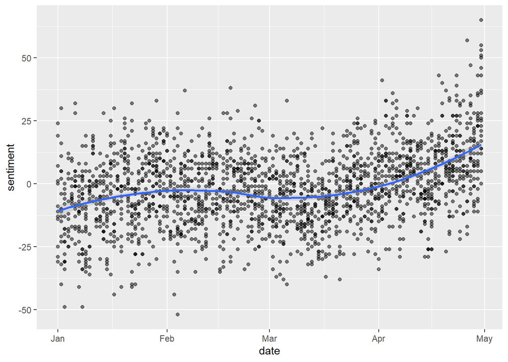

```r
tweets_nrc_sentiment %>%
  ggplot(aes(date, sentiment)) + #plot it in ggplot date vs sentiment
  geom_point(alpha=0.5) +
  geom_smooth(method= loess, alpha=0.25)
```

How do our different sentiment dictionaries look when compared to each other? We can then plot the sentiment scores over time for each of our sentiment dictionaries like so:

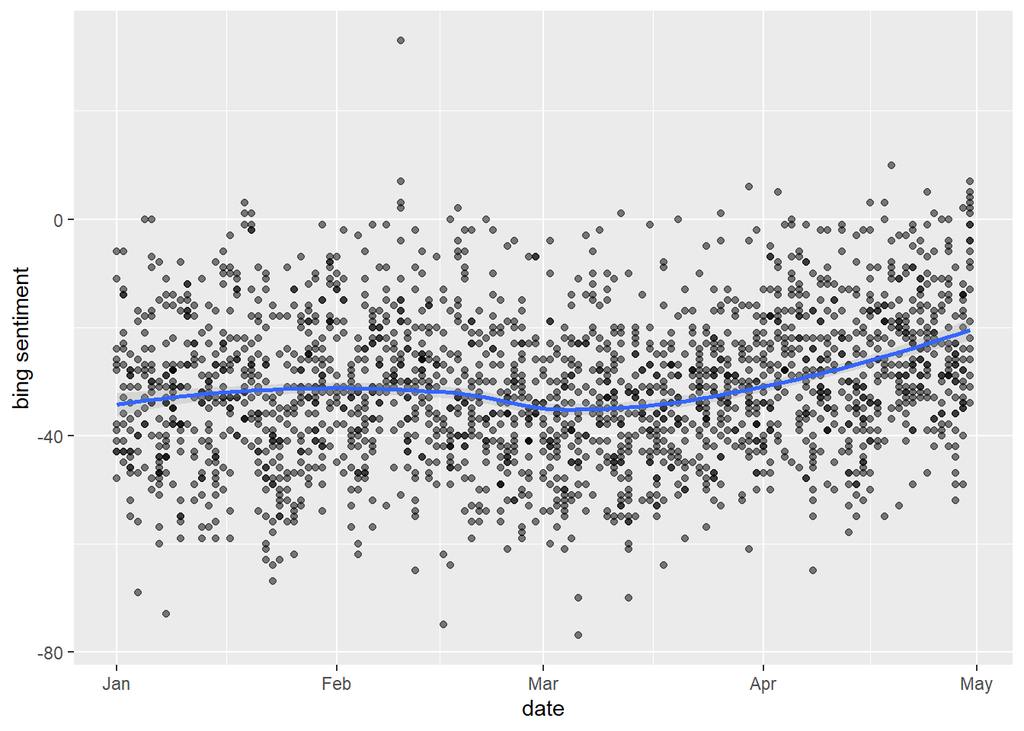

```r
tidy_tweets %>%
  inner_join(get_sentiments("bing")) %>% #BING dictionary
  count(date, index = order %/% 1000, sentiment) %>%
  spread(sentiment, n, fill = 0) %>%
  mutate(sentiment = positive - negative) %>%
  ggplot(aes(date, sentiment)) +
  geom_point(alpha=0.5) +
  geom_smooth(method= loess, alpha=0.25) +
  ylab("bing sentiment")
```

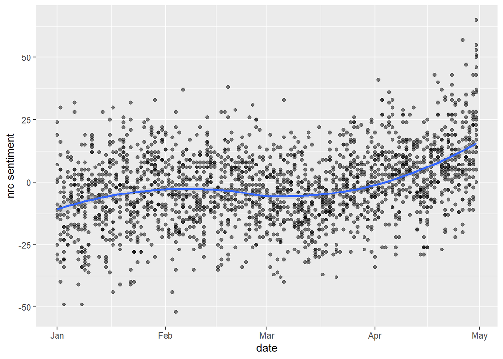

```r
tidy_tweets %>%
  inner_join(get_sentiments("nrc")) %>% #NRC dictionary
  count(date, index = order %/% 1000, sentiment) %>%
  spread(sentiment, n, fill = 0) %>%
  mutate(sentiment = positive - negative) %>%
  ggplot(aes(date, sentiment)) +
  geom_point(alpha=0.5) +
  geom_smooth(method= loess, alpha=0.25) +
  ylab("nrc sentiment")
```

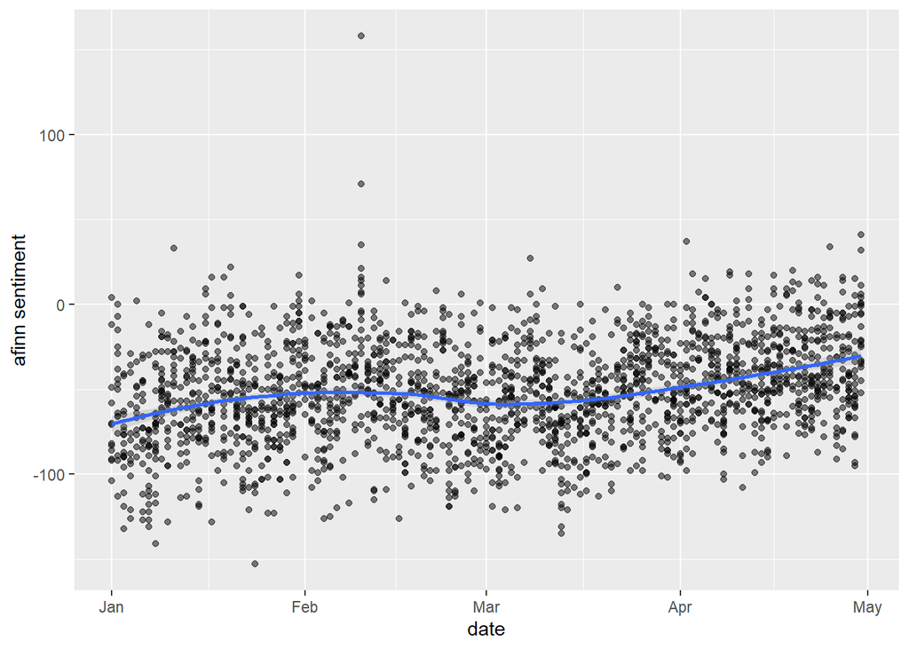

```r
tidy_tweets %>%
  inner_join(get_sentiments("afinn")) %>% #AFINN
  group_by(date, index = order %/% 1000) %>%
  summarise(sentiment = sum(value)) %>%
  ggplot(aes(date, sentiment)) +
  geom_point(alpha=0.5) + #scatter plot
  geom_smooth(method= loess, alpha=0.25) +
  ylab("afinn sentiment")
```

We see that they do look pretty similar… and interestingly it seems that overall sentiment positivity *increases* as the pandemic breaks.

## Domain-specific lexicons

Of course, list- or dictionary-based methods need not only focus on sentiment, even if this is one of their most common uses. In essence, what you’ll have seen from the above is that sentiment analysis techniques rely on a given lexicon and score words appropriately. And there is nothing stopping us from making our own dictionaries, whether they measure sentiment or not. In the data above, we might be interested, for example, in the prevalence of mortality-related words in the news. As such, we might choose to make our own dictionary of terms. What would this look like?

A very minimal example would choose, for example, words like “death” and its synonyms and score these all as 1. We would then combine these into a dictionary, which we’ve called “mordict” here.

```r
#create a list of words associated to mortality
word <- c('death', 'illness', 'hospital', 'life', 'health',
             'fatality', 'morbidity', 'deadly', 'dead', 'victim')
value <- c(1, 1, 1, 1, 1, 1, 1, 1, 1, 1) #assign a value to the words 1 being mortality related
mordict <- data.frame(word, value) #make dictionary/data frame with word n value
mordict
```

```
##         word value
## 1      death     1
## 2    illness     1
## 3   hospital     1
## 4       life     1
## 5     health     1
## 6   fatality     1
## 7  morbidity     1
## 8     deadly     1
## 9       dead     1
## 10    victim     1
```

We could then use the same technique as above to bind these with our data and look at the incidence of such words over time. Combining the sequence of scripts from above we would do the following:

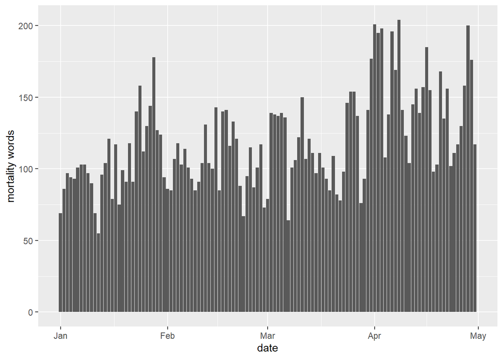

```r
tidy_tweets %>% #bind mordict to data and look at instances over time
  inner_join(mordict) %>%
  group_by(date, index = order %/% 1000) %>%
  summarise(morwords = sum(value)) %>%
  ggplot(aes(date, morwords)) +
  geom_bar(stat= "identity") + #barchart / freq chart
  ylab("mortality words")
```

The above simply counts the number of mortality words over time. This might be misleading if there are, for example, more or longer tweets at certain points in time; i.e., if the length or quantity of text is not time-constant.

An alternative, and preferable, method here would simply take a character string of the relevant words. We would then sum the total number of words across all tweets over time. Then we would filter our tweet words by whether or not they are a mortality word or not, according to the dictionary of words we have constructed. We would then do the same again with these words, summing the number of times they appear for each date.

After this, we join with our data frame of total words for each date. Note that here we are using `full_join()` as we want to include dates that appear in the “totals” data frame that do not appear when we filter for mortality words; i.e., days when mortality words are equal to 0. We then go about plotting as before.

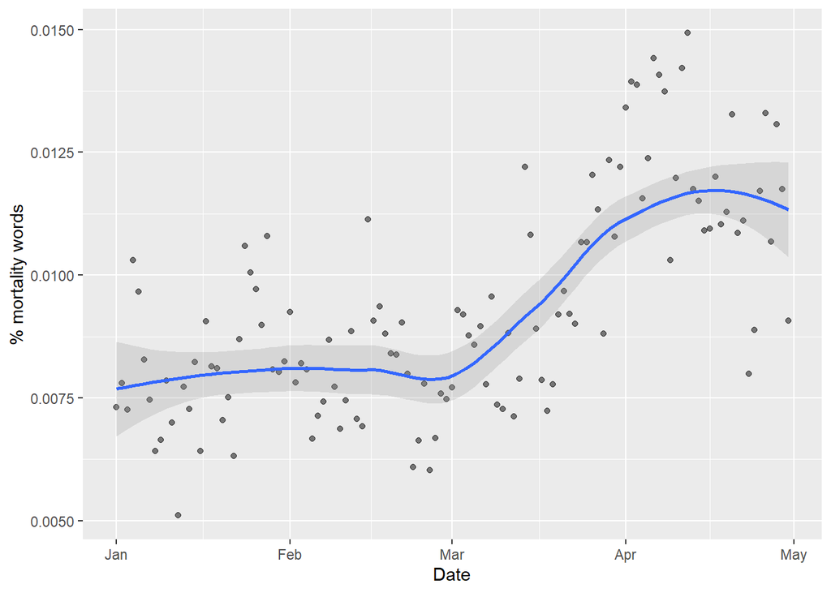

```r
mordict <- c('death', 'illness', 'hospital', 'life', 'health',
             'fatality', 'morbidity', 'deadly', 'dead', 'victim')

#get total tweets per day (no missing dates so no date completion required)
totals <- tidy_tweets %>%
  mutate(obs=1) %>%
  group_by(date) %>%
  summarise(sum_words = sum(obs))

#plot
tidy_tweets %>%
  mutate(obs=1) %>%
  filter(grepl(paste0(mordict, collapse = "|"),word, ignore.case = T)) %>%
  group_by(date) %>%
  summarise(sum_mwords = sum(obs)) %>%
  full_join(totals, word, by="date") %>% #include dates whre there are no mort word, you dont want to exclude
  mutate(sum_mwords= ifelse(is.na(sum_mwords), 0, sum_mwords),
         pctmwords = sum_mwords/sum_words) %>%
  ggplot(aes(date, pctmwords)) +
  geom_point(alpha=0.5) + #scatter plot
  geom_smooth(method= loess, alpha=0.25) + #line of best fit
  xlab("Date") + ylab("% mortality words") #x n y axes
```

## Using Lexicoder

The above approaches use general dictionary-based techniques that were not designed for domain-specific text such as news text. The Lexicoder Sentiment Dictionary, by @young_affective_2012 was designed specifically for examining the affective content of news text. In what follows, we will see how to implement an analysis using this dictionary.

We will conduct the analysis using the `quanteda` package. You will see that we can tokenize text in a similar way using functions included in the quanteda package.

With the `quanteda` package we first need to create a “corpus” object, by declaring our tweets a corpus object. Here, we make sure our date column is correctly stored and then create the corpus object with the `corpus()` function. Note that we are specifying the `text_field` as “tweet” as this is where our text data of interest is, and we are including information on the date that tweet was published. This information is specified with the `docvars` argument. You’ll see then that the corpus consists of the text and so-called “docvars,” which are just the variables (columns) in the original dataset. Here, we have only included the date column.

```r
tweets$date <- as.Date(tweets$created_at)#make sure date column stored correctly


tweet_corpus <- corpus(tweets, text_field = "tweet", docvars = "date",) #make a corpus object for use in quanteda pkge, docvars includes info on when tweet was published
#WARNING 'docvars' argument is not used
```

We then tokenize our text using the `tokens()` function from quanteda, removing punctuation along the way:

```r
toks_news <- tokens(tweet_corpus, remove_punct = TRUE) #tokenize the text and remove punctuation
```

We then take the `data_dictionary_LSD2015` that comes bundled with `quanteda` and and we select only the positive and negative categories, excluding words deemed “neutral.” After this, we are ready to “look up” in this dictionary how the tokens in our corpus are scored with the `tokens_lookup()` function.

```r
# select only the "negative" and "positive" categories
data_dictionary_LSD2015_pos_neg <- data_dictionary_LSD2015[1:2]#Only pos and neg categories

toks_news_lsd <- tokens_lookup(toks_news, dictionary = data_dictionary_LSD2015_pos_neg) #look up how the tokens in corpus are stored
```

This creates a long list of all the texts (tweets) annotated with a series of ‘positive’ or ‘negative’ annotations depending on the valence of the words in that text. The creators of `quanteda` then recommend we generate a document feature matrix from this. Grouping by date, we then get a dfm object, which is a quite convoluted list object that we can plot using base graphics functions for plotting matrices.

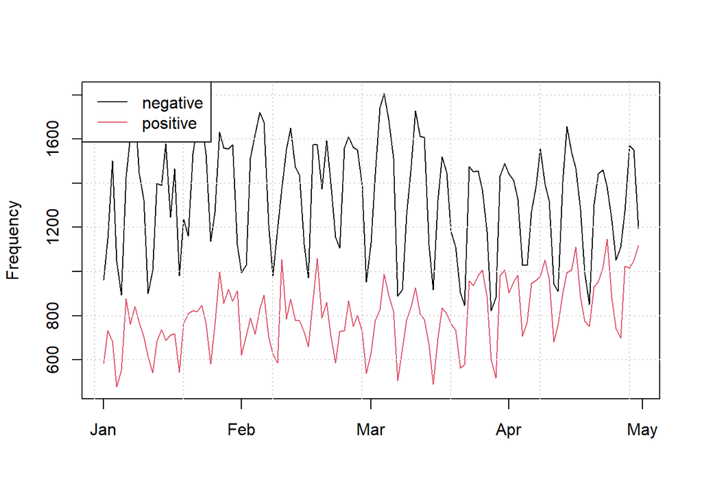

```r
# create a document document-feature matrix and group it by date
dfmat_news_lsd <- dfm(toks_news_lsd) %>%
  dfm_group(groups = date)

# plot positive and negative valence over time
matplot(dfmat_news_lsd$date, dfmat_news_lsd, type = "l", lty = 1, col = 1:2,
        ylab = "Frequency", xlab = "")
grid()
legend("topleft", col = 1:2, legend = colnames(dfmat_news_lsd), lty = 1, bg = "white")
```

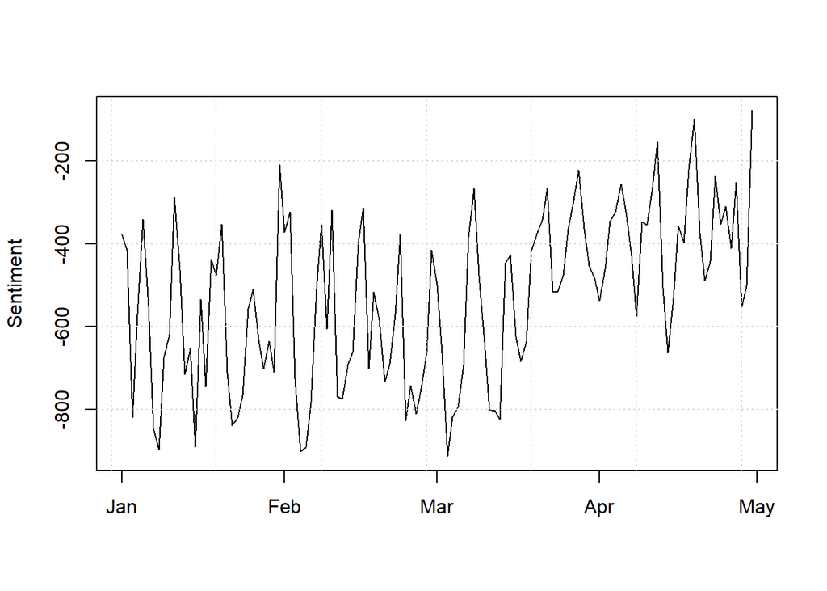

```r
# plot overall sentiment (positive  - negative) over time

plot(dfmat_news_lsd$date, dfmat_news_lsd[,"positive"] - dfmat_news_lsd[,"negative"],
     type = "l", ylab = "Sentiment", xlab = "")
grid()
abline(h = 0, lty = 2)
```

Alternatively, we can recreate this in tidy format as follows:

```r
negative <- dfmat_news_lsd@x[1:121]
positive <- dfmat_news_lsd@x[122:242]
date <- dfmat_news_lsd@Dimnames$docs


tidy_sent <- as.data.frame(cbind(negative, positive, date))

tidy_sent$negative <- as.numeric(tidy_sent$negative)
tidy_sent$positive <- as.numeric(tidy_sent$positive)
tidy_sent$sentiment <- tidy_sent$positive - tidy_sent$negative
tidy_sent$date <- as.Date(tidy_sent$date)
```

And plot accordingly:

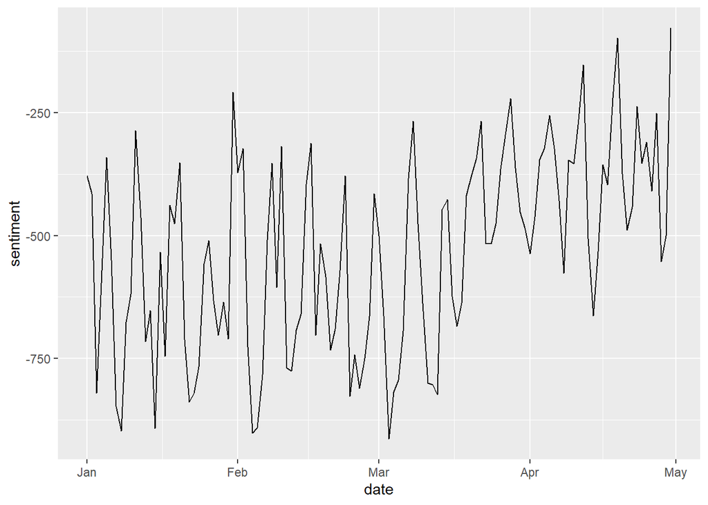

```r
tidy_sent %>%
  ggplot() +
  geom_line(aes(date, sentiment))
```

## Exercises

1. Take a subset of the tweets data by “user_name” These names describe the name of the newspaper source of the Twitter account. Do we see different sentiment dynamics if we look only at different newspaper sources?
2. Build your own (minimal) dictionary-based filter technique and plot the result
3. Apply the Lexicoder Sentiment Dictionary to the news tweets, but break down the analysis by newspaper
4. Don’t forget to ‘knit’ to produce your final html output for the exercise.
5. Apply the Lexicoder Sentiment Dictionary to the news tweets, but break down the analysis by newspaper

```r
tweets$date <- as.Date(tweets$created_at)#make sure date column stored correctly
#maybe I need to do something here for newspaper to store right? or maybe is in df correctly already
tweet_corpus <- corpus(tweets,
                       text_field = "tweet",
                       docvars = data.frame(date = tweets$date, newspaper = tweets$newspaper)) #make a corpus object for use in quanteda pkge, docvars includes info on when tweet was published

toks_news <- tokens(tweet_corpus, remove_punct = TRUE) #tokenize the text and remove punctuation


data_dictionary_LSD2015_pos_neg <- data_dictionary_LSD2015[1:2]#Only pos and neg categories

toks_news_lsd <- tokens_lookup(toks_news, dictionary = data_dictionary_LSD2015_pos_neg)#look up how the tokens in corpus are stored

#create a doc document-feature matrix and group it by date
dfmat_news_lsd <- dfm(toks_news_lsd) %>%
  dfm_group(groups = date)

# plot overall sentiment (positive  - negative) over time by newspaper

plot(dfmat_news_lsd$date, dfmat_news_lsd[,"positive"] - dfmat_news_lsd[,"negative"],
     type = "l", ylab = "Sentiment", xlab = "")
grid()
abline(h = 0, lty = 2)
```

```r
tweets$date <- as.Date(tweets$created_at)#make sure date column stored correctly
#maybe I need to do something here for newspaper to store right? or maybe is in df correctly already
tweet_corpus <- corpus(tweets,
                       text_field = "tweet",
                       docvars = data.frame(date = tweets$date, newspaper = tweets$newspaper)) #make a corpus object for use in quanteda pkge, docvars includes info on when tweet was published
toks_news <- tokens(tweet_corpus, remove_punct = TRUE) #tokenize the text and remove punctuation


data_dictionary_LSD2015_pos_neg <- data_dictionary_LSD2015[1:2]#Only pos and neg categories, apply dictionary

toks_news_lsd <- tokens_lookup(toks_news, dictionary = data_dictionary_LSD2015_pos_neg)#look up how the tokens in corpus are stored

#create a document document-feature matrix and group it by date
dfmat_news_lsd <- dfm(toks_news_lsd) %>%
dfm_group(groups = date, newspaper)

negative <- dfmat_news_lsd@x[1:121] #get neg feature from quanteda dfm, why 1:121?
positive <- dfmat_news_lsd@x[122:242] #get pos feature
date <- dfmat_news_lsd@Dimnames$docs #get date feature
newspaper <- docvars(dfmat_news_lsd, "newspaper") #get newspaper as a var from dfm

#combine it all into df
tidy_sent <- as.data.frame(cbind(negative, positive, date, newspaper))

#get the numeric vals and calc sentiment
tidy_sent$negative <- as.numeric(tidy_sent$negative)#makes num
tidy_sent$positive <- as.numeric(tidy_sent$positive)#makes num
tidy_sent$sentiment <- tidy_sent$positive - tidy_sent$negative #calc overall sentiment
tidy_sent$date <- as.Date(tidy_sent$date)#format as date

#plot overall sentiment over time with a line for each newspaper
tidy_sent %>%
  ggplot()+
  geom_line(aes(date, sentiment, color = newspapers))
#group n color by newspaper
```